# Homework 1

BenLarson

February 13, 2016

# 1 Expectation of Sufficient Statistics

a.Show that E[T(X)|$\eta$] = $\triangledown(A(\eta))$  
Start with the identity:  
$\int p(x) = 1$ $p(x) = h(x)*exp(\eta T(X)-A(\eta)) = 1$  
We take the derivate of the integral with repsect to $\eta$ to simplify the integral. $\frac{d}{d\eta} \int{h(x)*exp(\eta T(X)-A(\eta))} = \frac{d}{d\eta}1$ $\int{ \frac{d}{d\eta} h(x)*exp(\eta T(X)-A(\eta))} =\frac{d}{d\eta} 1$ Chain rule gives us the original function multiplied by the derivative of the terms in the exponent. $\int{ h(x)*exp(\eta T(X)-A(\eta)) * (T(X) - A'(\eta))}dx = 0$ $E[T(X)] - A'(\eta) = 0$ $E[T(X)] = A'(\eta)$ b. Verify with the for Gaussian distribution with unknown $\mu$ and known $\sigma^2$.  
$N(\mu,\sigma^2) = \frac{1}{\sqrt{2\pi}*\sigma}e^{-\frac{(x-\mu)^2}{2\sigma^2}}$ We drop the normalizing constants for easy math: $= e^{-\frac{1}{2\sigma^2}(x^2+2x\mu+\mu^2)}$ $= e^{-\frac{x^2}{2\sigma^2}-\frac{2x\mu}{2\sigma^2}-\frac{\mu^2}{2\sigma^2}}$ We now find the components that are in the exponential family, and find the parameters: $C = \frac{-x^2}{2\sigma^2} B = \frac{-2\mu x}{2\sigma^2} A = \frac{=\mu^2}{2\sigma^2}$ We seperate the parts have have a square with the parameter, constant with parameter and no parameter into their respective components. $h(x) = \frac{-x^2}{2\sigma^2} \\ T(x) = \frac{x}{\sigma}$ $A(\eta) = \frac{\mu^2}{2\sigma^2} \\ \eta = \frac{\mu}{\sigma}$  
We can now compare our gaussian with the formula above: $E(x|\mu) = \mu$ T(x) = x and $\eta = \mu$ for a gaussian distribution,  
$A'(\eta) = \frac{d}{d\mu}\frac{\mu^2}{2\sigma^2} = \frac{2\mu}{2\sigma^2} = \mu$ if we consider $\sigma$ to be 1. Our equations are therefor correct.

# 2 Noninformative priors for the poisson distribution

1. rewrite in exponential family form:  
   $P(X=k; \lambda) = \frac{\lambda^k e^{-\lambda}}{k!}$ $= exp(ln(\frac{\lambda^k e^{-\lambda}}{k!}))$ $= exp(ln(\lambda^k)-\lambda-ln(k!))$ $= exp(k *ln(\lambda)-\lambda-ln(k!))$ Now that the formula is in exponential faimly form, we can find teh sufficient statistic T(X) and natural parameter $\eta$. $A(\lambda) = k*ln(\lambda) \\ \eta= -\lambda \\ T(x) = -ln(k!)$
2. 2 different non-informative priors for $p(\lambda)$.  
   b.1 uniform distribution from $\lambda \in [0,k)$. We assume this is plausible because we can’t have negative events happening, which is what he poison distribution is modeling.  
   b.2 Jererys’ prior: $p(\lambda) = \sqrt{I(\lambda)} = \sqrt{E[\frac{d}{d\lambda} ln(p(x|\lambda))]^2}$ an alternate definition is given by: $p(\lambda) = \sqrt{I(\lambda)} = \sqrt{E[\frac{d^2}{d^2\lambda} ln(p(x|\lambda))]}$ from the definiton in our textbook (Gelman et al, Bayesian Data Analysis, pg 88) which I found easier to compute $\sqrt{E[\frac{d^2}{d^2\lambda} ln(p(x|\lambda))]} = \sqrt{E[\frac{d^2}{d^2\lambda} ln(\frac{\lambda^k e^{-k}}{k!})]}= \sqrt{E[\frac{d^2}{d^2\lambda} k*ln(\lambda)+ln(e^{-\lambda})-ln(k!)]}$ $\sqrt{E[\frac{d}{d\lambda} \frac{k}{\lambda}-1 -0]} = \sqrt{E[\frac{1}{\lambda^2}|\lambda]} = \sqrt{\frac{\lambda}{\lambda^2}} = \sqrt{\frac{1}{\lambda}}$ the last step follows from the conditional expectation: $E[\frac{d^2}{d^2\lambda} ln(p(x|\lambda))|\lambda] = \frac{\lambda}{\lambda^2}$
3. Posteriors for the 2 prior options:  
   Uniform prior(0,$k$) $\frac{1}{0-k}$ $\int \frac{\lambda^k e^{-\lambda}}{k!} * \frac{1}{0-\inf} = \int \frac{\lambda^k e^{-\lambda}}{k!} * \frac{1}{k} = \frac{1}{-k} poisson(\lambda)$ 1/-k being the normalizing factor.

Poisson posterior with Jeffreys’ prior: $\int \frac{(\lambda)^k e^{-(\lambda)}}{k!} \frac{1}{(\lambda)^{1/2}} = \frac{1}{k!} \int (\lambda)^{k-1/2} e^{-\lambda} d\lambda$ = gamma distribution = $\frac{(\beta)^{alpha}}{\Gamma(\alpha)}=(\lambda)^{\alpha-1}e^{-\beta\lambda}$ $\alpha = k+\frac{1}{2} \\ \beta = 1$

# 3 Non-Conjugate Priors, What is the posterior pdf $p(\mu|x_i;\sigma^2,a,b)$

uniform distribution = $\frac{1}{b-a}$ wich is our prior distribution for paramter $\mu$  
normal distribution = $\prod e^{\frac{1}{2\sigma^2}(xi-\mu)^2} = e^{\frac{1}{2\sigma^2}^n(\sum_{i=0}^n{x_i-\mu)^2}}$ Which is our likelihood function for the data X given parameters $\mu,\sigma$

$\frac{\frac{1}{b-a}*e^{\frac{1}{2\sigma^2}^n(\sum_{i=0}^n{xi-\mu)^2}}}{\int_{-\infty}^{\infty} e^{(\frac{1}{2\sigma^2})^n(\sum_{i=0}^n{x_i-\mu)^2}}d\mu }$

# 4

# I did not get results that I expected. I have documented my code hoping for partial credit

First I used the code given to setup the data into 3 groups.

```r
## Read in the cross-sectional OASIS data, including hippocampal volumes
x = read.csv("/Users/Benjamin/Documents/PROBMOD/Hwk2/oasis_cross-sectional.csv")
y = read.csv("/Users/Benjamin/Documents/PROBMOD/Hwk2/oasis_hippocampus.csv")
hippo = merge(x, y, by = "ID")

## Let's look at only elderly subjects
hippo = hippo[hippo$Age >= 60,]
rownames(hippo) = NULL

## Create three categories of subjects according to dementia level (from CDR)
## Controls: CDR = 0, Mild Dementia: CDR = 0.5, Dementia: CDR >= 1.0
hippo$Group[hippo$CDR == 0.0] = "Control"
hippo$Group[hippo$CDR == 0.5] = "Mild"
hippo$Group[hippo$CDR >= 1.0] = "Dementia"
hippo$Group = factor(hippo$Group, levels=c("Control", "Mild", "Dementia"))

## Here are some example plots of the data
# ggplot(hippo, aes(x = RightHippoVol, fill = Group)) + geom_density(alpha=0.5)
# boxplot(RightHippoVol ~ Group, data = hippo)

u1 = mean(hippo[which(hippo$Group=="Control"),"RightHippoVol"])
u2 = mean(hippo[which(hippo$Group=="Mild"),"RightHippoVol"])
u3 = mean(hippo[which(hippo$Group=="Dementia"),"RightHippoVol"])
s1 = var(hippo[which(hippo$Group=="Control"),"RightHippoVol"])
s2 = var(hippo[which(hippo$Group=="Mild"),"RightHippoVol"])
s3 = var(hippo[which(hippo$Group=="Dementia"),"RightHippoVol"])
n1 = hippo[which(hippo$Group=="Control"),"RightHippoVol"]
n2 = hippo[which(hippo$Group=="Mild"),"RightHippoVol"]
n3 = hippo[which(hippo$Group=="Dementia"),"RightHippoVol"]
bn = hippo[,"RightHippoVol"]
```

Dinverse gamma distribution using x as input, and alpha beta parameters, given to us from class website.

```r
## Density function for Inverse Gamma: conjugate prior for Gaussian sigma^2
dinvgamma = function(x, alpha, beta)
{
  beta^alpha / gamma(alpha) * x^(-alpha - 1) * exp(-beta / x)
}
```

Normal Inverse Gamma, This is where I suspect errors in my code. This function takes m, s which are 2 arrays to solve over, which gives you a two dimensional matrix using hyper parameters as instructed in the homework for the prior distriubtion of $\mu, \sigma$. This function was used for the prior.

```r
## Density function for Normal-Inverse-Gamma
## with parameters mu0, lambda, alpha, beta
dninvg = function(m, s, mu0 = 0, lambda = 10e-6, alpha = 10e-6, beta = 10e-6)
{
  dnorm(m, mean = mu0, sd = sqrt(s / lambda)) * dinvgamma(s, alpha, beta)
}
```

This functions solves for the likelihood function for Y = $N(x,\mu,\sigma^2)$. Input was the data. Log was taken to simplify the math and keep the exponents from being 0 or NA as was the case.

```r
## Likelihood function
gausslik = function(x, sigmaSqr)
{
  gn = length(x)
  # gn*log(sum(1 / sqrt(2 * pi * sigmaSqr)^(gn/2))) * -sum(x^2) / (2 * sigmaSqr)
  # r = 1 / (2 * pi * sigmaSqr)^(gn/2) * exp(-sum(x^2) / (2 * sigmaSqr))
#   -log(r)
   -1*((gn/2)*log(1 / (2 * pi * sigmaSqr))+ (-sum(x^2) - (2*sigmaSqr)))
}
```

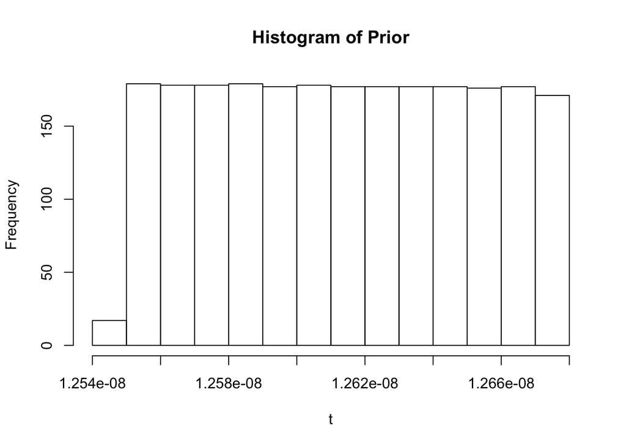

```r
## Density function for Posterior Distribution P(u,var)
postInv = function(n)
{
  sd = sqrt(var(bn))
  m = seq(mean(bn)-2*sqrt(var(bn)),mean(bn)+2*sqrt(var(bn)),1)/mean(bn)
  s = seq(var(bn)-2*sqrt(var(bn)),var(bn)+2*sqrt(var(bn)),1)/var(bn)
#   mu0 =
#   lambda =
#   alpha =
#   beta =
  f.iso = outer(m,s,FUN=dninvg)
  # x = rnorm(length(n),mean=,sd=s)
  gausslik(n, sigmaS = var(n))*f.iso
}
#just for plotting the prior dist.
n = n1
m = seq(mean(bn)-2*sqrt(var(bn)),mean(bn)+2*sqrt(var(bn)),1)/mean(bn)
s = seq(var(bn)-2*sqrt(var(bn)),var(bn)+2*sqrt(var(bn)),1)/var(bn)
t = dninvg(m,s)
hist(t, main = paste("Histogram of Prior"))
```

I now tried to find the marginal posterior function by $\int p(\mu,\sigma^2|y)d\mu$. Basically I summed all the columns (from the posterior dist matrix) into 1 row, because that would be the equivalent of a distribution of $\sum^{\mu} p(\mu,\sigma^2|y) = p(\sigma|y)$. The following contour plot is a clear indicator that my posterior distributino is not correct. I’m getting a flat line, rather than some sort of rounded contoured gaussian that I would expect.

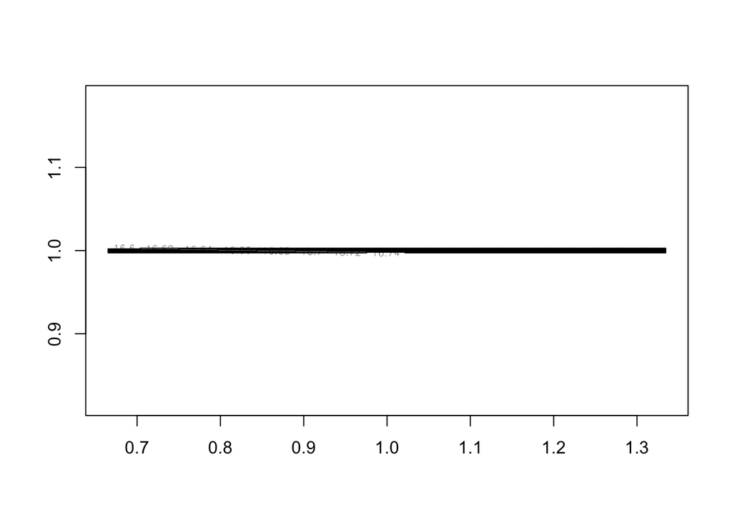

```r
samplePostMargVar = function(amount,data){
  x.iso = postInv(data)
  x.iso = colSums(x.iso)
  sample(x = x.iso, amount, replace=TRUE)
}
contour(m, s, postInv(n1), asp = 1)
```

The same reasoning and setup for mariginalizing $p(\mu|y)$ I just summed the rows together from the posterior density matrix.

```r
samplePostMargMean = function(amount,s,data){
  postInv(data,s)
  x.iso = postInv(data,s)
  x.iso = rowSums(x.iso)
  sample(x = x.iso, amount, replace=TRUE)
}
```

Plotting histogram of the marginal posterior density $p(\sigma_1|y_{i1})$

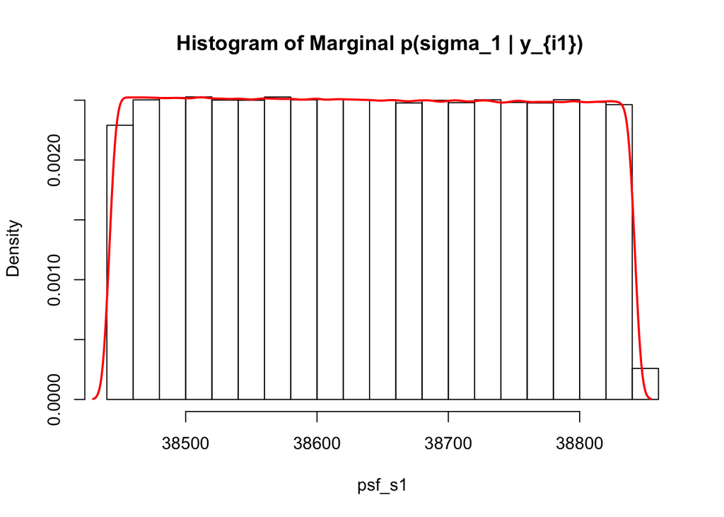

```r
# Attempt to plot data
x.iso = postInv(n1)
x.iso = colSums(x.iso)
psf_s1 = samplePostMargVar(10e6,n1)
hist(psf_s1, prob =TRUE, main = paste("Histogram of Marginal p(sigma_1 | y_{i1}) "))
# # hist(psf_s1, col = 'blue', freq=FALSE)
lines(density(psf_s1),col = 'red', lwd=2)
abline(v = s1, col = 'black', lwd = 5)
```

Plot the posterior marginal distriubtions $p(\mu_1|y_{i1})$, $p(\mu_2|y_{i2})$, and $p(\mu_3|y_{i3})$

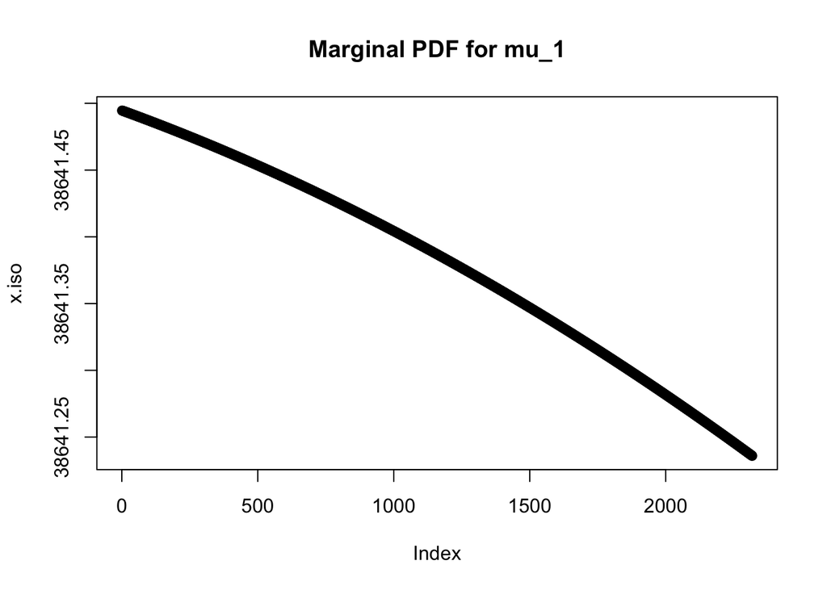

```r
x.iso = postInv(n1)
x.iso = rowSums(x.iso)

x2.iso = postInv(n2)
x2.iso = rowSums(x2.iso)

x3.iso = postInv(n3)
x3.iso = rowSums(x3.iso)

plot(x.iso, main = "Marginal PDF for mu_1")
abline(h = u1, col = 'black', lwd = 5)
```

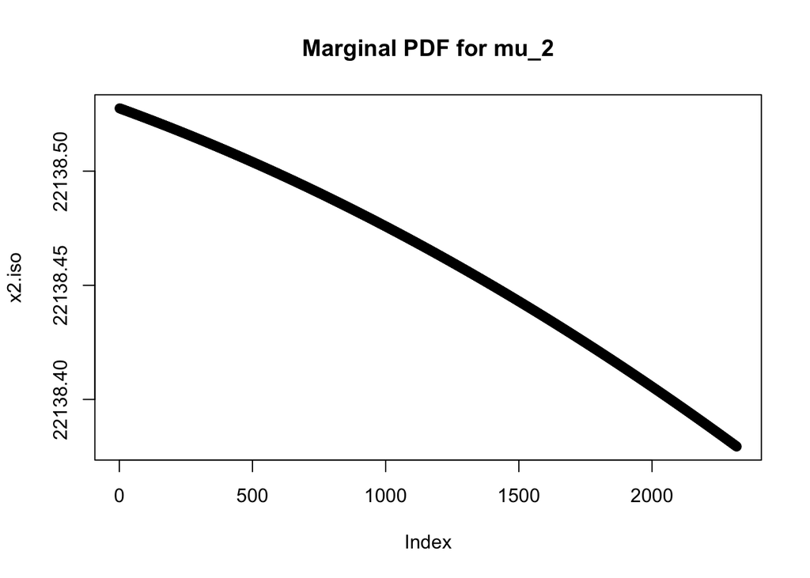

```r
plot.new()
frame()
plot(x2.iso, main = "Marginal PDF for mu_2")
abline(h = u1, col = 'black', lwd = 5)
```

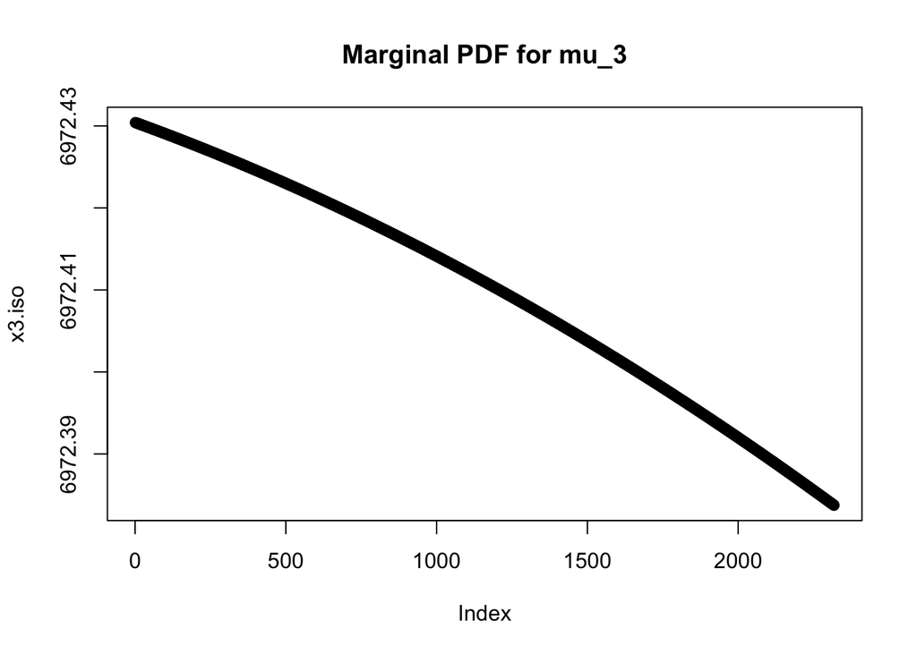

```r
plot.new()
frame()
plot(x3.iso, main = "Marginal PDF for mu_3")
abline(h = u1, col = 'black', lwd = 5)
```